# MF9155

Group 2: Julie Johannessen, Pia Skovholt Halvorsen and Kristin Elisabeth Wickstrøm

November/December 2023

# 1 Intro and stuff

Group work report for day 2 and day 3 of MF9155

.. but first:

## 1.1 Motivational memes

### 1.1.1 Relatable

[figure not shown]

### 1.1.2 Relatable

[figure not shown]

# 2 Day 2

## 2.1 EDA (Exploratory Data Analysis)

### 2.1.1 Task: Reproduce Table 1

```r
# gender distribution
clinic %>%
  filter(Type == "MDS") %>%
  dplyr::count(Gender)
```

```
##   Gender   n
## 1      0 102
## 2      1  57
```

```r
# find range of Age
range(clinic$Age, na.rm = TRUE)
```

```
## [1] 19 87
```

```r
# find median of Age
median(clinic$Age, na.rm=TRUE)
```

```
## [1] 67
```

```r
# NA count for Age in MDS patients
sum(is.na(clinic$Age) & clinic$Type == "MDS")
```

```
## [1] 5
```

```r
# subset for mds classification characteristics
clinic %>%
  mutate(WHO_category = case_when(
    WHO_category == "RAEB 1" ~ "RAEB",
    WHO_category == "RAEB 2" ~ "RAEB",
    WHO_category == "RAEB1" ~ "RAEB",
    WHO_category == "RAEB2" ~ "RAEB",
    TRUE ~ WHO_category
  )) %>%
  filter(Type == "MDS") %>%
  dplyr::count(WHO_category)
```

```
##    WHO_category  n
## 1           5q-  6
## 2       AML-MDS  7
## 3          CMML  7
## 4            RA 13
## 5          RAEB 56
## 6          RARS 14
## 7        RARS-T  6
## 8          RCMD 27
## 9       RCMD-RS 22
## 10         <NA>  1
```

*Notes on EDA*

- When replicating age and gender data, it becomes clear that age and gender of the control samples er unknown
- MDS classification is found in the column named “WHO_category”
- To replicate the MDS classification of table 1, we have to match the names of RAEB samples. We also have to account for only MDS patients

### 2.1.2 Task: Exploration of the gene expression matrix

- What kind of information do you get when simply typing `gset` (i.e. the name of the data object) into the Console?
- What is the dimension of the expression data matrix? How many samples (patients) and how many gene expression features?

```r
gset
```

```
## ExpressionSet (storageMode: lockedEnvironment)
## assayData: 22503 features, 176 samples
##   element names: exprs
## protocolData: none
## phenoData
##   rowNames: GSM1420393 GSM1420394 ... GSM1420568 (176 total)
##   varLabels: PDID GEOID ... age_imp (90 total)
##   varMetadata: labelDescription
## featureData: none
## experimentData: use 'experimentData(object)'
## Annotation:
```

```r
dim(gset)
```

```
## Features  Samples
##    22503      176
```

# 3 Day 3

## 3.1 Unsupervised learning

### 3.1.1 PCA calculation on subset of gset

```r
# Workaround in case of error message when scale=TRUE
# (because some genes have variance 0):
vars <- apply(t(exprs(gset)), 2, var)
gset.forPCA <- gset[vars>0,] # subset and removes variables with variance equal 0
pca <- prcomp(t(exprs(gset.forPCA)), scale=TRUE)
```

### 3.1.2 PCA plot per mutation

```r
# generate colors for SF3B1 mutation
col.SF3B1 <- rep("gray", length=ncol(gset)) # replicate vector for length of all columns in gset
col.SF3B1[clinic$SF3B1==1] <- "#e41a1c" # add color for patients with mutation in SF3B1

# generate different point types for missing and non-missing data
pch.SF3B1 <- ifelse(is.na(clinic$SF3B1), 1, 19)
```

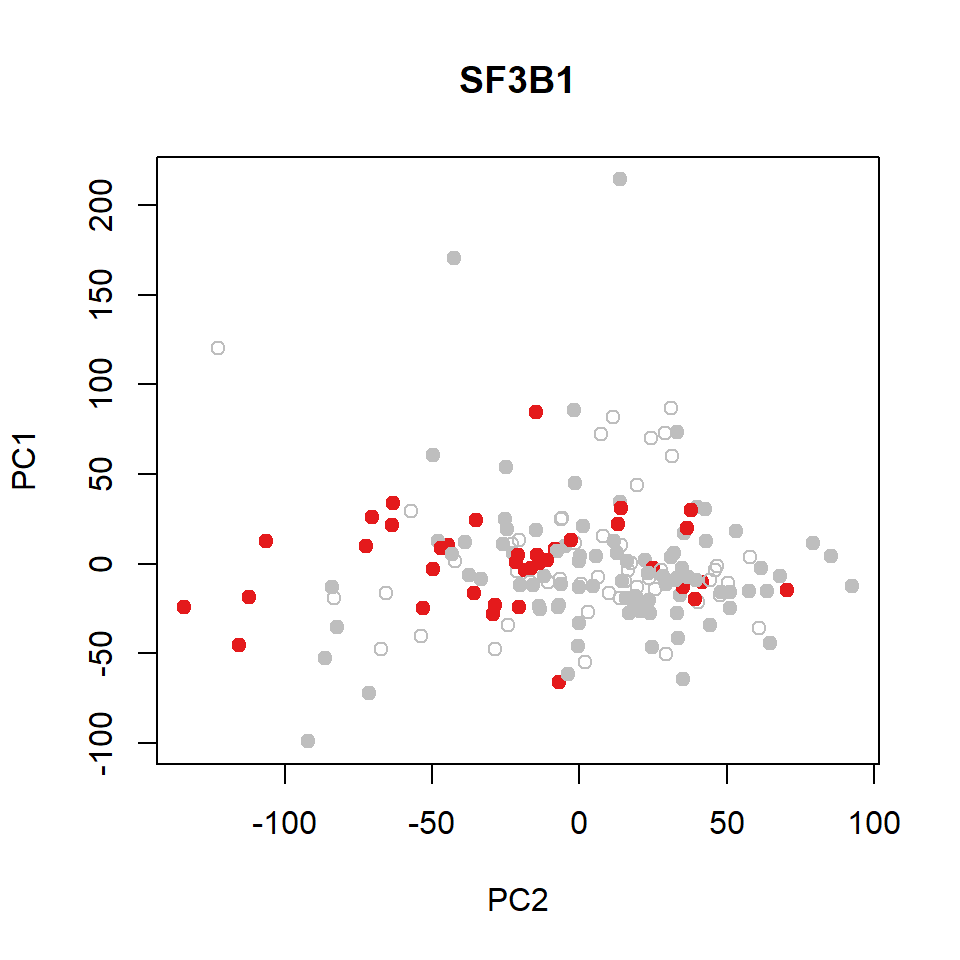

Gerstung et al. (2015), Figure 1a: Pairwise Scatterplot

```r
# make pairwise scatterplot of principal components:
plot(x=pca$x[,1], y=pca$x[,2], col=col.SF3B1, pch=pch.SF3B1,
     ylab="PC1", xlab="PC2", main="SF3B1")
```

### 3.1.3 Alternative version for recreating PCA plot in Figure 1A

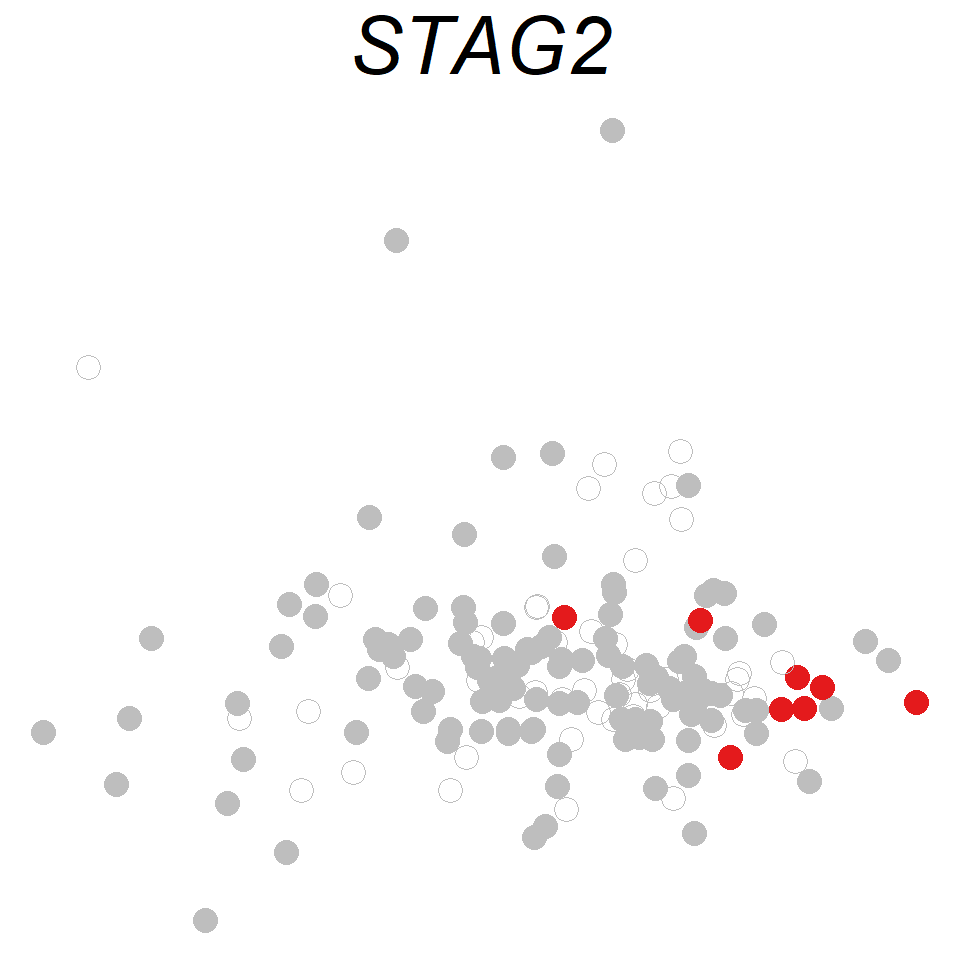

```r
# ggplot version where we can change variable and recreate plot
col_interest <- "STAG2" # choose column of interest

col.int <- rep("gray", length=ncol(gset)) # replicate vector for length of all columns in gset
col.int[clinic[[col_interest]] == 1] <- "#e41a1c" # add color for patients with mutation
pch.int <- ifelse(is.na(clinic[[col_interest]]), 1, 19)


as.data.frame(pca$x) %>%
  ggplot(aes(PC1, PC2)) +
  geom_point(col=col.int, shape=pch.int, size =4) +
  labs(title = col_interest) +
  theme_void() +
  theme(plot.title = element_text(hjust = 0.5,
                                  size=30,
                                  family ="sans",
                                  face="italic"))
```

**Notes**

- We don’t get exactly the same PCA plot as in the paper for some reason?
- In the paper, it seems like they are overlaying PCA plot for the variable of choice above the basic PCA plot instead of changing color of the variable only

## 3.2 Hierarchical clustering

```r
# for each gene, calculate the variance over all samples
vs <- apply(exprs(gset),1,var)

# order the genes by decreasing variance
oo <- order(vs,decreasing=TRUE)

# select the 1000 genes with the largest variances
gep <- exprs(gset)[oo[1:1000],]
```

### 3.2.1 Task: vs and sd distributions

- Summarise the distribution of `vs` (=variances) and of `sqrt(vs)` (=standard deviations) graphically. What is the cutoff for the variance that corresponds to our choice of keeping the 1000 genes with largest variance? Do you think this cutoff was a sensible choice? – **we show distributions with histograms**
- Look at `oo` carefully. Make sure that you understand what the data entries in this vector mean. – **It does not actually sort the vs vector- it provides the indices that you would use to sort the variances. Each number equals to that value’s position in a potential sorted array**
- Would you have chosen a different cutoff values for the variance? How many genes would you have kept with your cutoff?

```r
#cutoff for variance in the subset of of 1000 genes
cutoff_vs <- min(gep)
cutoff_vs
```

```
## [1] 2.254394
```

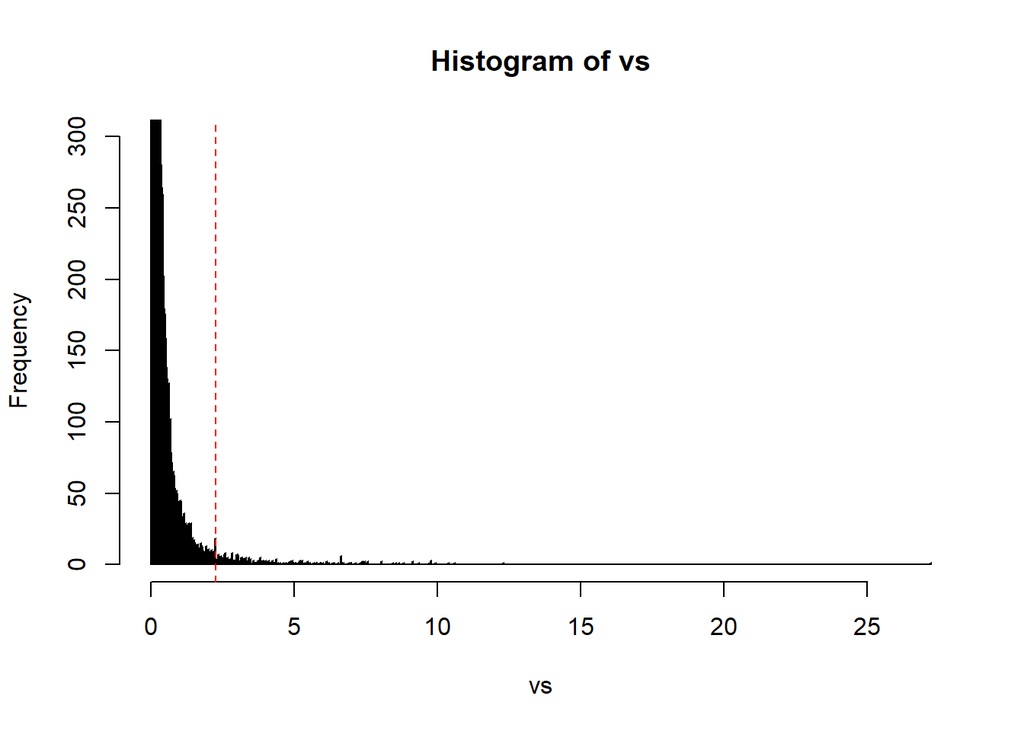

```r
# distribution of vs
hist(vs,breaks=1000, ylim = c(0,300)) |># ylim to be able to see low frequency counts
  abline(v = cutoff_vs, col = "red", lty = "dashed")
```

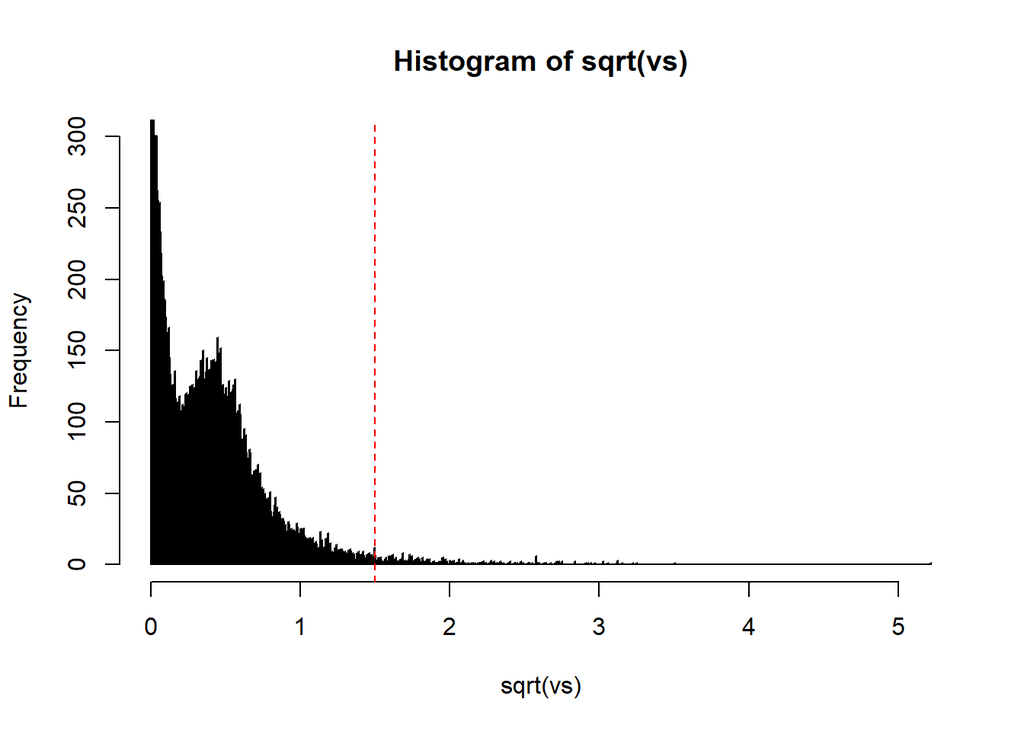

```r
# distribution sd (sqrt(vs))
hist(sqrt(vs),breaks=1000, ylim=c(0,300)) |>
  abline(v = sqrt(cutoff_vs), col = "red", lty = "dashed")
```

### 3.2.2 Task: Perform hierarchical clustering using Pearson correlation.

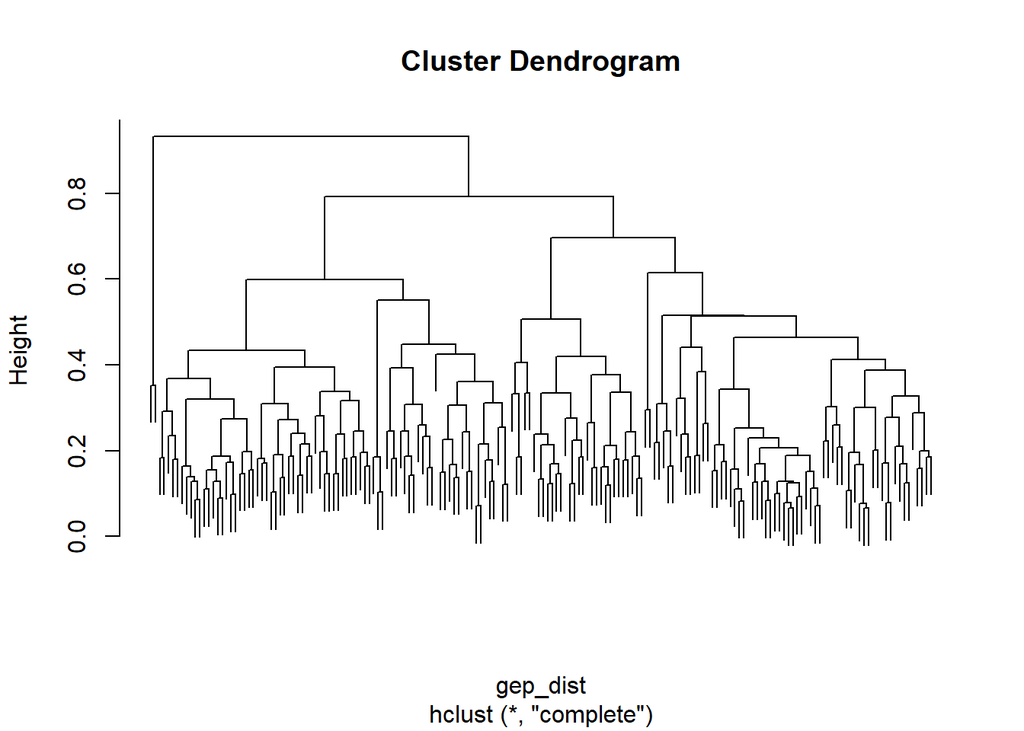

```r
cor_pearson <- cor(gep, method = "pearson")

gep_dist <- as.dist(1-cor_pearson)

hc <- hclust(gep_dist)

#plot dendogram
plot(hc,labels = FALSE)
```